# Exploratory Analysis

## Project title

Correlation of Taxes and Energy Consumption

### Authors

Amy Balala, Aryan Auti, Timothy Dillon, Shuai LaVielle

### Date

Winter 2023

### Abstract

We will be analyzing certain aspects of the U.S. economy including taxes and energy consumption and how/ if they are correlated. There is ample data to analyze data from year to year to determine if certain patterns happen consistently or only in certain timeframes. Furthermore, each of these categories have numerous subcategories that can be explored like utility tax etc.

### Keywords

Taxes, Energy Consumption, Income, Annual Rates

### Introduction

The economy is ever evolving in the United States, but one might wonder if a pattern has persisted throughout our recent history. We plan to tackle that curiosity by analyzing several questions and introducing data from several related topics. 1) The first question we have is what kind of pattern there is with taxes from year to year. The results from exploring the question seem like they might be intuitive and we predict there will be a steady rise in taxes from year to year, but if not then more questions will arise (see 1942). 2) From there, we will analyze a simimlar question when it comes to energy consumption. We beleive it will follow the same pattern with a steady increase, but it will also be interesting to see what sectors use the most energy and if that has changed over time. 3) Another intriguing concept that could be gleaned from the data is how closely related the trend in taxes and energy consumption is. We could analyze this using a one to one ratio of megaWatts to dollars, and check the numbers from 1960 until present day. If the pattern isn’t linear it could raise questions like: are we using less energy comparatively? Are we more energy efficient? Have taxes been raised or lowered? and many more.

### Related Work

There are many studies done related to taxes, income, energy consumption, and the economy. One that closely analyzes the relationship between taxes and income is titled *Measuring Taxes on Income from Capital* by Michael P. Devereux. Specifically, Devereux dives into the exact proportionality of income and taxes and how a balance is achieved. Another article, *Environmental taxes, energy consumption, and environmental quality: Theoretical survey with policy implications* by Umer Shazad takes a look at how taxes can actually be used to reduce energy consumption and that they can be a benefit to the environment. It can be seen that many of these topics are very closely correlated with one another. Taxes have a relation to both income and energy consumption, but another article *Effects of financial developments and income on energy consumption* shows that income and energy and energy are related as well. The article states that in developing countries as their production and financial development increases, so does their energy consumption. With these articles and many more, the correlation between these economic topics is clear, but many of the articles only focus on a broad overview and don’t introduce much hard data. With the data we have we can connect all of those points.

- [Measuring Taxes on Income from Capital](https://books.google.com/books?hl=en&lr=&id=G4ZBDba7iEcC&oi=fnd&pg=PA35&dq=taxes+and+income&ots=fnv3CXCGIy&sig=5oYmm32P7CqGE2iKKQ4Y4BoHRVk#v=onepage&q=taxes%20and%20income&f=false)
- [Environmental taxes, energy consumption, and environmental quality: Theoretical survey with policy implications](https://link.springer.com/article/10.1007/s11356-020-08349-4)
- [Effects of financial developments and income on energy consumption](https://www.sciencedirect.com/science/article/pii/S1059056014001130)

### The Dataset

We found data about energy usage in each state from the Energy Information Administration’s website. This is the statistical branch of the Department of Energy. We were able to find data related to taxes from the government’s census website. All our datasets were available as CSVs.

- [This is the link to the energy data](https://www.eia.gov/state/seds/sep_use/total/csv/use_all_phy.csv) This dataset has 8116 observations and 64 features
- [This is the link to the tax collection data](https://www2.census.gov/programs-surveys/stc/datasets/historical/STC_Historical_2021.zip) This dataset has 3867 observations and 36 features

The energy consumption dataset was compiled by the EIA of the Department of Energy. The EIA collects, analyzes, and disseminates independent and impartial energy information to promote sound policymaking, efficient markets, and public understanding of energy and its interaction with the economy and the environment. Moreover, by law, the EIA’s data, analyses, and forecasts are independent of approval by any other officer or employee of the U.S. government. This implies some degree of impartiality in the data. The EIA collects information from multiple energy power plants through two annual surveys. However, as each plant cannot be accessed every month, they use statistical imputation to estimate monthly operational characteristics of the energy industry. The tax collection dataset was compiled by the United States Census Bureau for the Annual Survey of State Government Tax Collections. This dataset was then made available on the United States Census Bureau website. This data was collected legally for the development of gross domestic product estimates, development of the national income and product accounts, and tax policy research. Most of the entries in the dataset are obtained through collection, some data may be estimated using coding operations and weighting. Specific information about the collection of this data was provided in the paper linked below:

[Data Collection Information](https://www2.census.gov/programs-surveys/stc/technical-documentation/methodology/2021stcmethodology.pdf)

One ethical question that was taken into consideration was whether our data was obtained legally through legitimate sources. Although information about income categories in a state was available, this information was not verified by government sources and so we decided not to use it. However, this ethical consideration also proved to be a limitation as we were not able to directly correlate income with energy usage. We had to first find the tax bracket that people belonged to get an ‘estimate’ of their household income. We plan to correlate this information with energy consumption data.

### Implications

Assuming we are able to answer our research questions, there are several possible implications for technologists, designers, and policymakers. One possible implication might arise from the extent to which tax rates and energy consumption are tied together. Should they be strongly correlated - as we expect - there may be room for future research into incentives or controls, beyond money, that would limit/reduce energy consumption among the highest users. Should they be negatively correlated, there may be further incentive for designers and policymakers to produce more affordable solutions and alternatives for energy use. Another possible implication might arise from which taxes produce the greatest amount of revenue. These findings may provide insight for policymakers looking at where revenue is being generated and where it is being put to use, as well as how these taxes might be changed in order to more fairly reflect the needs and behaviors of different communities.

### Table

```r
# Load Data Sets
taxes <- read.csv("https://raw.githubusercontent.com/info-201a-wi23/exploratory-analysis-timmythehatter/main/STC_Historical_2021_cleaned.csv")
energy <- read.csv("https://www.eia.gov/state/seds/sep_use/total/csv/use_all_phy.csv")

# Remove X's from years in energy dataframe
colnames(energy) <- sub("X", "", colnames(energy))

# Remove all commas from taxes
taxes <- taxes%>%mutate(C105 = str_replace_all(taxes$C105, ",", ""))
taxes <- taxes%>%mutate(T15 = str_replace_all(taxes$T15, ",", ""))

# Remove first row of taxes
taxes_removed <- taxes%>%slice(-1)

# Find the total per year of energy used
energy_per_year <- apply(energy[, 4:length(energy)], 2, sum, na.rm = TRUE)
energy_per_year <- data.frame(energy_per_year)
years <- data.frame(Year = as.numeric(row.names(energy_per_year)))
energy_per_year <- cbind(energy_per_year, years)

# Find the taxes per year
taxes_per_year <- taxes_removed%>%group_by(Year)%>%summarize(average_taxes = mean(as.double(C105), na.rm = TRUE))

# Ratio Per Year of Taxes to Energy
tax_v_energy <- left_join(energy_per_year, taxes_per_year, by = "Year")
tax_v_enery_ratio <- tax_v_energy%>%mutate(ratio = average_taxes / energy_per_year)
```

### Chart 1

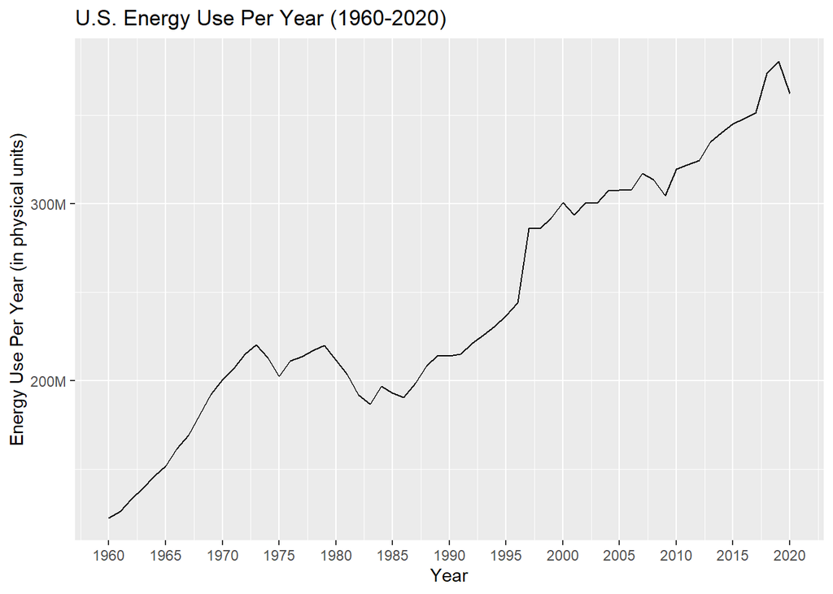

This chart visualizes the changes in U.S. energy use per year, highlighting different periods of growth and decline over the past 60 years.

The chart shows how dramatically energy consumption has grown in the U.S. since the 1960s - jumping from around 120 million physical units per year to 362 million per year. The chart also shows a large decline in consumption in the first-half of the 1980s, as well as smaller downturns in 1975, 2001, and 2008. These periods of decline can be attributed to factors such as the 1970s oil crisis and economic recessions. Notably, the chart also indicates the beginning of another decline starting in 2019 and into 2020. This could be attributable to the COVID-19 pandemic and the host of economic policies implemented in response.

### Chart 2

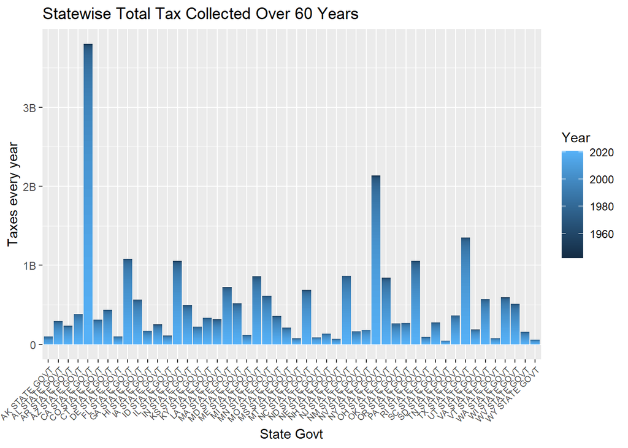

This chart visualizes all the taxes collected in each state year wise over 60 years.

This chart shows how tax collection patterns vary across states in all sectors over 60 years. It does so by representing yearly total of the taxes collected in each state as a stacked bar plot, segregated by years. This data may be important in drawing correlations between the states where most energy is consumed versus states where the highest taxes have been collected. Moreover, this taxation data also hints at the spending and earning ability of the people in these states. Furthermore, the chart also shows that majority of the taxation has occurred over recent years, post 1990s. This is similar to the trend represented by the energy consumption graph.

### Chart 3

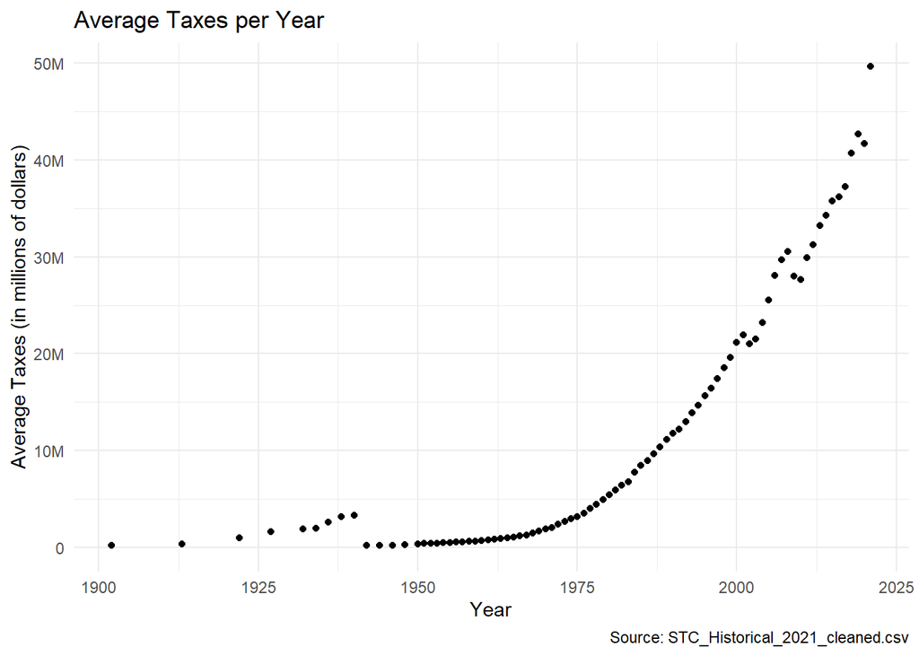